# Ensemble

Monte Carlo ensemble simulations

This module implements Monte Carlo ensemble simulations with parameter perturbations for probabilistic fire spread forecasting.

```julia
using Elmfire
using Plots
using Random
Random.seed!(42)
```

```
TaskLocalRNG()
```

## Types

### PerturbationConfig

Configuration for stochastic parameter perturbations.

```julia
struct PerturbationConfig{T<:AbstractFloat}
    ignition_perturb_radius::T         # Radius for ignition point perturbation (cells)
    wind_speed_factor_range::Tuple{T,T}  # (min, max) multiplier for wind speed
    wind_direction_std::T              # Standard deviation for wind direction (degrees)
    moisture_factor_range::Tuple{T,T}  # (min, max) multiplier for fuel moisture
    spread_rate_factor_range::Tuple{T,T}  # (min, max) multiplier for spread rate
end
```

**Constructor:**

```julia
PerturbationConfig{T}(;
    ignition_perturb_radius = 0.0,
    wind_speed_factor_range = (1.0, 1.0),
    wind_direction_std = 0.0,
    moisture_factor_range = (1.0, 1.0),
    spread_rate_factor_range = (1.0, 1.0)
)
```

```julia
# No perturbations (deterministic)
perturb_none = PerturbationConfig{Float64}()

# Moderate perturbations
perturb_moderate = PerturbationConfig{Float64}(
    ignition_perturb_radius = 2.0,
    wind_speed_factor_range = (0.8, 1.2),
    wind_direction_std = 15.0,
    moisture_factor_range = (0.9, 1.1)
)

# High uncertainty
perturb_high = PerturbationConfig{Float64}(
    ignition_perturb_radius = 5.0,
    wind_speed_factor_range = (0.6, 1.4),
    wind_direction_std = 30.0,
    moisture_factor_range = (0.7, 1.3)
)
```

```
PerturbationConfig{Float64}(5.0, (0.6, 1.4), 30.0, (0.7, 1.3), (1.0, 1.0))
```

### EnsembleConfig

Configuration for ensemble simulation runs.

```julia
struct EnsembleConfig{T<:AbstractFloat}
    n_simulations::Int                   # Number of ensemble members
    base_seed::UInt64                    # Base random seed for reproducibility
    perturbation::PerturbationConfig{T}  # Perturbation settings
    simulation_config::SimulationConfig{T}  # Base simulation configuration
    save_individual_results::Bool        # Save individual member results
end
```

**Constructor:**

```julia
EnsembleConfig{T}(;
    n_simulations = 100,
    base_seed = UInt64(12345),
    perturbation = PerturbationConfig{T}(),
    simulation_config = SimulationConfig{T}(),
    save_individual_results = false
)
```

```julia
config = EnsembleConfig{Float64}(
    n_simulations = 50,
    base_seed = UInt64(42),
    perturbation = perturb_moderate,
    save_individual_results = true
)

println("Ensemble size: $(config.n_simulations)")
println("Base seed: $(config.base_seed)")
```

```
Ensemble size: 50
Base seed: 42
```

### EnsembleMember

Results from a single ensemble member simulation.

```julia
struct EnsembleMember{T<:AbstractFloat}
    id::Int                      # Member ID (1 to n_simulations)
    seed::UInt64                 # Random seed used
    burned::BitMatrix            # Burned area
    time_of_arrival::Matrix{T}   # Time of arrival
    burned_area_acres::T         # Total burned area
    max_spread_rate::T           # Maximum spread rate
end
```

### EnsembleResult

Aggregated results from an ensemble of simulations.

```julia
mutable struct EnsembleResult{T<:AbstractFloat}
    config::EnsembleConfig{T}
    members::Vector{EnsembleMember{T}}  # Individual results (if saved)
    burn_probability::Matrix{T}         # Probability of each cell burning
    mean_arrival_time::Matrix{T}        # Mean arrival time (for cells that burn)
    std_arrival_time::Matrix{T}         # Std dev of arrival time
    mean_burned_area::T                 # Mean burned area across ensemble
    std_burned_area::T                  # Std dev of burned area
    convergence_history::Vector{T}      # RMS change in burn probability
end
```

## Functions

### run_ensemble!

Run a Monte Carlo ensemble of fire simulations.

```julia
run_ensemble!(
    config::EnsembleConfig{T},
    state_template::FireState{T},
    fuel_ids::Matrix{Int},
    fuel_table::FuelModelTable{T},
    weather::ConstantWeather{T},
    slope::Matrix{T},
    aspect::Matrix{T},
    ignition_ix::Int, ignition_iy::Int,
    t_start::T, t_stop::T;
    show_progress = true
) -> EnsembleResult{T}
```

```julia
# Setup
ncols, nrows = 80, 80
fuel_table = create_standard_fuel_table(Float64)

weather = ConstantWeather{Float64}(
    wind_speed_mph = 12.0,
    wind_direction = 270.0,
    M1 = 0.06, M10 = 0.08, M100 = 0.10,
    MLH = 0.60, MLW = 0.90
)

fuel_ids = fill(1, ncols, nrows)
slope = zeros(Float64, ncols, nrows)
aspect = zeros(Float64, ncols, nrows)
state_template = FireState{Float64}(ncols, nrows, 30.0)

# Run small ensemble
config = EnsembleConfig{Float64}(
    n_simulations = 30,
    base_seed = UInt64(42),
    perturbation = PerturbationConfig{Float64}(
        wind_speed_factor_range = (0.8, 1.2),
        wind_direction_std = 20.0
    )
)

result = run_ensemble!(
    config,
    state_template,
    fuel_ids, fuel_table, weather,
    slope, aspect,
    40, 40,  # Ignition point
    0.0, 25.0;
    show_progress = false
)

println("Mean burned area: $(round(result.mean_burned_area, digits=1)) acres")
println("Std burned area: $(round(result.std_burned_area, digits=1)) acres")
```

```
Mean burned area: 10.4 acres
Std burned area: 2.2 acres
```

### run_ensemble_threaded!

Run ensemble using multiple threads for parallel execution.

```julia
run_ensemble_threaded!(
    config::EnsembleConfig{T},
    state_template::FireState{T},
    fuel_ids::Matrix{Int},
    fuel_table::FuelModelTable{T},
    weather::ConstantWeather{T},
    slope::Matrix{T},
    aspect::Matrix{T},
    ignition_ix::Int, ignition_iy::Int,
    t_start::T, t_stop::T;
    show_progress = true
) -> EnsembleResult{T}
```

This function distributes ensemble members across available threads for faster execution.

### perturb_weather

Apply stochastic perturbations to weather conditions.

```julia
perturb_weather(weather::ConstantWeather{T}, config::PerturbationConfig{T}, rng) -> ConstantWeather{T}
```

```julia
base_weather = ConstantWeather{Float64}(
    wind_speed_mph = 15.0,
    wind_direction = 270.0,
    M1 = 0.06, M10 = 0.08, M100 = 0.10,
    MLH = 0.60, MLW = 0.90
)

perturb = PerturbationConfig{Float64}(
    wind_speed_factor_range = (0.7, 1.3),
    wind_direction_std = 25.0,
    moisture_factor_range = (0.8, 1.2)
)

rng = MersenneTwister(42)

println("Base weather: $(base_weather.wind_speed_20ft) mph from $(base_weather.wind_direction)°")
println("\nPerturbed samples:")
for i in 1:5
    w = perturb_weather(base_weather, perturb, rng)
    println("  $(round(w.wind_speed_20ft, digits=1)) mph from $(round(w.wind_direction, digits=0))°, M1=$(round(w.M1, digits=3))")
end
```

```
Base weather: 15.0 mph from 270.0°

Perturbed samples:
  16.9 mph from 268.0°, M1=0.059
  12.1 mph from 268.0°, M1=0.055
  14.5 mph from 269.0°, M1=0.053
  14.7 mph from 265.0°, M1=0.067
  13.9 mph from 237.0°, M1=0.051
```

### perturb_ignition

Perturb ignition location within a given radius.

```julia
perturb_ignition(ix::Int, iy::Int, radius::T, ncols::Int, nrows::Int, rng) -> Tuple{Int, Int}
```

### compute_burn_probability

Compute burn probability from ensemble members.

```julia
compute_burn_probability(members::Vector{EnsembleMember}, ncols::Int, nrows::Int) -> Matrix{T}
```

### compute_mean_arrival_time

Compute mean arrival time from ensemble members.

```julia
compute_mean_arrival_time(members::Vector{EnsembleMember}, ncols::Int, nrows::Int) -> Matrix{T}
```

### aggregate_ensemble_statistics!

Update aggregated statistics in an EnsembleResult.

```julia
aggregate_ensemble_statistics!(result::EnsembleResult)
```

### check_convergence

Check if the ensemble has converged based on burn probability stability.

```julia
check_convergence(result::EnsembleResult, threshold::T = T(0.01)) -> Bool
```

### get_exceedance_probability

Get probability of burned area exceeding a threshold.

```julia
get_exceedance_probability(result::EnsembleResult, area_threshold::T) -> T
```

```julia
# What's the probability of burning more than 2 acres?
prob_exceed = get_exceedance_probability(result, 2.0)
println("P(burned area > 2 acres) = $(round(prob_exceed * 100, digits=1))%")
```

```
P(burned area > 2 acres) = 100.0%
```

### get_percentile_fire

Get the ensemble member closest to a given percentile of burned area.

```julia
get_percentile_fire(result::EnsembleResult, percentile::T) -> EnsembleMember
```

## Visualization

### Burn Probability Map

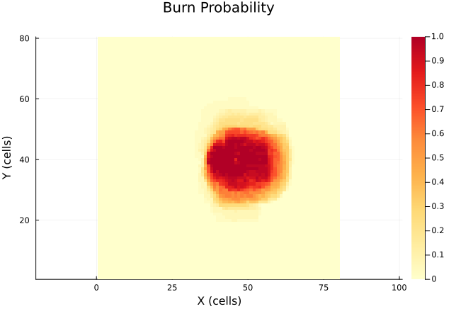

```julia
heatmap(result.burn_probability',
    title = "Burn Probability",
    color = :YlOrRd,
    clims = (0, 1),
    aspect_ratio = 1,
    xlabel = "X (cells)",
    ylabel = "Y (cells)"
)
```

### Comparing Percentiles

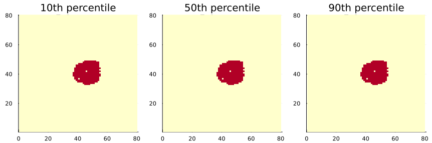

```julia
# Run larger ensemble for percentile analysis
config_large = EnsembleConfig{Float64}(
    n_simulations = 50,
    base_seed = UInt64(123),
    perturbation = PerturbationConfig{Float64}(
        wind_speed_factor_range = (0.7, 1.3),
        wind_direction_std = 25.0
    ),
    save_individual_results = true
)

result_large = run_ensemble!(
    config_large, state_template,
    fuel_ids, fuel_table, weather,
    slope, aspect, 40, 40, 0.0, 25.0;
    show_progress = false
)

# Get percentile fires
p10 = get_percentile_fire(result_large, 0.10)
p50 = get_percentile_fire(result_large, 0.50)
p90 = get_percentile_fire(result_large, 0.90)

plots_arr = [
    heatmap(p10.burned', title = "10th percentile\n$(round(p10.burned_area_acres, digits=1)) acres",
        color = :YlOrRd, aspect_ratio = 1, colorbar = false),
    heatmap(p50.burned', title = "50th percentile\n$(round(p50.burned_area_acres, digits=1)) acres",
        color = :YlOrRd, aspect_ratio = 1, colorbar = false),
    heatmap(p90.burned', title = "90th percentile\n$(round(p90.burned_area_acres, digits=1)) acres",
        color = :YlOrRd, aspect_ratio = 1, colorbar = false)
]

plot(plots_arr..., layout = (1, 3), size = (900, 300))
```

### Burned Area Distribution

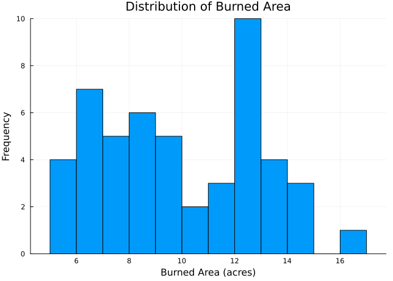

```julia
if !isempty(result_large.members)
    areas = [m.burned_area_acres for m in result_large.members]

    histogram(areas,
        xlabel = "Burned Area (acres)",
        ylabel = "Frequency",
        title = "Distribution of Burned Area",
        bins = 15,
        legend = false
    )
end
```

## Best Practices

### Ensemble Size

- **Small ensembles (20-50)**: Quick analysis, rough probability estimates
- **Medium ensembles (100-200)**: Good balance of accuracy and speed
- **Large ensembles (500+)**: High-precision probability maps, convergence testing

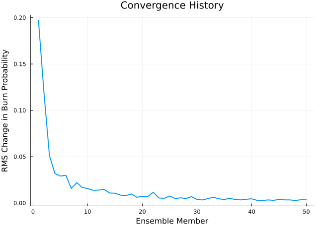

```julia
# Check convergence history
if !isempty(result_large.convergence_history)
    plot(result_large.convergence_history,
        xlabel = "Ensemble Member",
        ylabel = "RMS Change in Burn Probability",
        title = "Convergence History",
        linewidth = 2,
        legend = false
    )
end
```

### Perturbation Settings

| Uncertainty Level | Wind Speed Range | Wind Dir Std | Moisture Range |
| --- | --- | --- | --- |
| Low | (0.9, 1.1) | 10° | (0.95, 1.05) |
| Moderate | (0.8, 1.2) | 20° | (0.85, 1.15) |
| High | (0.7, 1.3) | 30° | (0.75, 1.25) |
| Very High | (0.5, 1.5) | 45° | (0.6, 1.4) |

### Reproducibility

Always set a base seed for reproducible results:

```julia
config = EnsembleConfig{Float64}(
    n_simulations = 100,
    base_seed = UInt64(12345)  # Set for reproducibility
)
```

Each ensemble member uses `base_seed + member_id` as its random seed.

## Parallel Execution

Use `run_ensemble_threaded!` for multi-core execution:

```julia
# Start Julia with multiple threads: julia -t 8
result = run_ensemble_threaded!(config, ...)
```

Thread scaling is approximately linear up to the number of physical cores.